## Author: Chindu

## Data Preparation

### *Cleaning/Feature engineering/Data manipulation*

A sample data of a travel industry is prepared for modelling purpose. The data set consists of 999 observations and 23 variables about customer enquiries about holiday packages. This dataset is prepared to create predictive models for predicting the ‘Booked.Status’.’Data for cleaning.csv’ is the input file and ‘ReadyforModelling.csv’ is the output file after the data preperation methods are carried out.

**List of library used:** library(lubridate), library(zoo), library(imputeTS), library(DataExplorer), library(data.table)

#### Read data and get a basic understanding of the data

```r
data<- read.csv("data for cleaning.csv")
head(data)
```

|  | Enquiry.Date | Enquiry.Time | Allocated.Time | Web.or.Phone | Answered.by.specialist | ConversationRCD | TempSent | Holiday.Type | Accom.type | Dep.Airport | Dep.Date | Lead.Time | Destination | Duration | Adults | Children | Infants | Transport.Type | Answered.Q | Notes.Completed | Title | Enquiry.Comments | Booked.Status |
| --- | --- | --- | --- | --- | --- | --- | --- | --- | --- | --- | --- | --- | --- | --- | --- | --- | --- | --- | --- | --- | --- | --- | --- |
| 1 | 5/29/2017 | 10:18:38 | Fast | WEB | Yes | 1 | 5 | B | grade2 | NC | 4/29/2018 | 48 | CC City | 14 | 2 | 0 | 0 | B | NO | NO | Ms | NO | YES |
| 2 | 5/14/2018 | 11:10 | Fast | WEB |  | 12 | 2 | C | grade1 | Any Airport | 10/14/2019 | 74 | AC | 14 | 4 | 2 | 1 | B | NO | NO | Ms | NO | YES |
| 3 | 11/4/2018 | 13:40 | Fast | PHONE | Yes | 7 | 3 | A | grade1 | MCH | 5/5/2019 | 26 | JH Area | 14 | 2 | 0 | 0 | A | YES | NO | Ms | YES | YES |
| 4 | 1/2/2019 | 11:09 | Fast | PHONE |  | 3 | 1 | A | grade2 | B | 7/10/2019 | 27 | DC Drive | 14 | 2 | 2 | 0 | B | YES | NO | Ms | NO | YES |
| 5 | 9/21/2018 | 13:12 | Fast | PHONE | Yes | 3 | 4 | B | grade2 | Lon All | 8/14/2019 | 47 | AC Keys | 17 | 2 | 2 | 0 | A | YES | NO | Ms | YES | YES |
| 6 | 9/18/2017 | 20:08:07 | Fast | PHONE |  | 11 | 6 | A | grade1 | MCH | 3/30/2018 | 27 | AB | 14 | 2 | 2 | 0 | A | NO | NO | Ms | NO | YES |

```r
dim(data)
```

```
## [1] 999  23
```

The dataset contains 999 observations with 23 variables

#### Check the structure of the dataset

```r
str(data)
```

```
## 'data.frame':    999 obs. of  23 variables:
##  $ Enquiry.Date          : Factor w/ 515 levels "1/1/2017","1/1/2018",..: 329 307 140 30 488 481 17 273 101 3 ...
##  $ Enquiry.Time          : Factor w/ 754 levels "0:02:38","0:10",..: 40 96 266 95 234 490 200 375 437 301 ...
##  $ Allocated.Time        : Factor w/ 3 levels "Extremely Fast",..: 2 2 2 2 2 2 2 2 2 2 ...
##  $ Web.or.Phone          : Factor w/ 2 levels "PHONE","WEB": 2 2 1 1 1 1 1 1 1 1 ...
##  $ Answered.by.specialist: Factor w/ 2 levels "","Yes": 2 1 2 1 2 1 1 2 2 2 ...
##  $ ConversationRCD       : int  1 12 7 3 3 11 0 21 7 1 ...
##  $ TempSent              : int  5 2 3 1 4 6 1 4 3 1 ...
##  $ Holiday.Type          : Factor w/ 6 levels "A","B","C","D",..: 2 3 1 1 2 1 1 1 5 1 ...
##  $ Accom.type            : Factor w/ 5 levels "","grade1","grade2",..: 3 2 2 3 3 2 2 3 1 3 ...
##  $ Dep.Airport           : Factor w/ 17 levels "AD","Any Airport",..: 17 2 16 3 12 16 13 12 12 12 ...
##  $ Dep.Date              : Factor w/ 550 levels "1/1/2018","1/11/2018",..: 240 24 305 352 430 195 186 288 167 436 ...
##  $ Lead.Time             : int  48 74 26 27 47 27 62 56 14 85 ...
##  $ Destination           : Factor w/ 35 levels " AA Resort"," AB",..: 9 3 17 13 4 2 2 1 12 1 ...
##  $ Duration              : int  14 14 14 14 17 14 14 14 14 14 ...
##  $ Adults                : int  2 4 2 2 2 2 3 2 3 1 ...
##  $ Children              : int  0 2 0 2 2 2 2 3 0 1 ...
##  $ Infants               : int  0 1 0 0 0 0 0 0 0 0 ...
##  $ Transport.Type        : Factor w/ 4 levels "","A","B","None Required": 3 3 2 3 2 2 3 3 2 3 ...
##  $ Answered.Q            : Factor w/ 2 levels "NO","YES": 1 1 2 2 2 1 2 1 2 2 ...
##  $ Notes.Completed       : Factor w/ 2 levels "NO","YES": 1 1 1 1 1 1 2 1 2 1 ...
##  $ Title                 : Factor w/ 5 levels "Dr","Miss","Mr",..: 5 5 5 5 5 5 5 5 5 5 ...
##  $ Enquiry.Comments      : Factor w/ 2 levels "NO","YES": 1 1 2 1 2 1 1 1 1 1 ...
##  $ Booked.Status         : Factor w/ 2 levels "No","YES": 2 2 2 2 2 2 2 2 2 2 ...
```

From understanding the structure, it is observed that variables such as Dep.Date,Enquiry.Date and Enquiry.Time have significant number of levels. It would be ideal to categorise them into larger groups. For example Dep.Date can be categorised into months or seasons, such analysis would allow us to get better insights from the data. It is also critical to check the structure in which R has identified each variable (factor, numerical, integet, etc). In this dataset, R has identified dates as factor. This should be coverted to date format.

Before further analysis, it is a good practice to eliminate variables which are not relevant to the analysis, in this case ConversationRCD as well as TempSent will be eliminated.

```r
data$TempSent<-NULL
data$ConversationRCD<-NULL
```

#### Convert Dep.Date and Enquiry.Date to date format

```r
data$Enquiry.Date<- as.character(data$Enquiry.Date)
data$Enquiry.Date<-mdy(data$Enquiry.Date)
data$Dep.Date<- as.character(data$Dep.Date)
data$Dep.Date<-mdy(data$Dep.Date)
```

#### Apply feature engineering to create various date related columns which might give us better insights

```r
data$EnquiryYear<-factor(year(data$Enquiry.Date))
data$EnquiryMonth<-factor(month(data$Enquiry.Date))
data$EnquiryDay<-day(data$Enquiry.Date)
data$EnquiryWeekday<-factor(weekdays(data$Enquiry.Date))
data$DepYear<-factor(year(data$Dep.Date))
data$DepMonth<-factor(month(data$Dep.Date))
data$DepDay<-day(data$Dep.Date)
data$DepWeekday<-factor(weekdays(data$Dep.Date))
```

#### Change Enquiry.time to various time related levels to give us better insights

```r
data$Enquiry.Time <- as.numeric(gsub("\\:.*$", "", data$Enquiry.Time))
data$Enquiry.Timecat<-ifelse(data$Enquiry.Time>=9 &
                               data$Enquiry.Time<=21,"Business_Hour","Closed")
data$Enquiry.Timecat<-factor(data$Enquiry.Timecat)

data$Enquiry.Time_class <- with(data,  ifelse(Enquiry.Time >= 6 &
                                                Enquiry.Time<=12, "morning",
                                       ifelse(Enquiry.Time>12 &
                                                Enquiry.Time<=18, "afternoon", "night")))
data$Enquiry.Time<- NULL
data$Enquiry.Time_class<-factor(data$Enquiry.Time_class)
```

#### Change Dep.Date to seasons this could give a better idea of popular destinations for each seasons

```r
yq <- as.yearqtr(as.yearmon(data$Dep.Date, "%m/%d/%Y") + 1/12)
data$DepartureSeason <- factor(format(yq, "%q"), levels = 1:4,
                               labels = c("winter", "spring", "summer", "fall"))
```

Since Enquiry.Date and Dep.Date has no further use in this analysis, these variables are removed

```r
data$Enquiry.Date<-NULL
data$Dep.Date<-NULL
```

#### Check for missing values

```r
colSums(is.na(data))
```

```
##         Allocated.Time           Web.or.Phone Answered.by.specialist
##                      0                      0                      0
##           Holiday.Type             Accom.type            Dep.Airport
##                      0                      0                      0
##              Lead.Time            Destination               Duration
##                      0                      0                     17
##                 Adults               Children                Infants
##                      0                      0                      0
##         Transport.Type             Answered.Q        Notes.Completed
##                      0                      0                      0
##                  Title       Enquiry.Comments          Booked.Status
##                      0                      0                      0
##            EnquiryYear           EnquiryMonth             EnquiryDay
##                      0                      0                      0
##         EnquiryWeekday                DepYear               DepMonth
##                      0                      0                      0
##                 DepDay             DepWeekday        Enquiry.Timecat
##                      0                      0                      0
##     Enquiry.Time_class        DepartureSeason
##                      0                      0
```

The variable Duration has missing values. Since only a small number of observations have missing values, it was decided that the missing values will be replace by the median value

```r
data$Duration<-na.mean(data$Duration,option="median")
```

To further understand the data, the summary function is used

```r
summary(data)
```

```
##         Allocated.Time Web.or.Phone Answered.by.specialist  Holiday.Type
##  Extremely Fast:259    PHONE:197       :490                A      :684
##  Fast          :135    WEB  :802    Yes:509                B      :136
##  Slow          :605                                        C      : 28
##                                                            D      : 34
##                                                            E      :115
##                                                            RV Tour:  2
##
##   Accom.type        Dep.Airport    Lead.Time          Destination
##        : 91   MCH         :314   Min.   :-10.00    AC       :323
##  grade1:379   Lon All     :289   1st Qu.: 30.00    AB       :233
##  grade2:476   Lon Gat     :141   Median : 48.00    JH Area  : 95
##  grade3: 52   GG          : 66   Mean   : 50.47    AA Resort: 91
##  None  :  1   Any Airport : 42   3rd Qu.: 67.00    DC Drive : 51
##               Lon Heathrow: 40   Max.   :140.00    CC City  : 42
##               (Other)     :107                    (Other)   :164
##     Duration         Adults         Children        Infants
##  Min.   : 1.00   Min.   : 1.00   Min.   :0.000   Min.   :  0.0000
##  1st Qu.:14.00   1st Qu.: 2.00   1st Qu.:0.000   1st Qu.:  0.0000
##  Median :14.00   Median : 3.00   Median :1.000   Median :  0.0000
##  Mean   :13.48   Mean   : 3.63   Mean   :0.955   Mean   :  0.2923
##  3rd Qu.:14.00   3rd Qu.: 4.00   3rd Qu.:2.000   3rd Qu.:  0.0000
##  Max.   :28.00   Max.   :18.00   Max.   :6.000   Max.   :255.0000
##
##        Transport.Type Answered.Q Notes.Completed  Title
##               :  5    NO :486    NO :712         Dr  :  4
##  A            :518    YES:513    YES:287         Miss:126
##  B            :252                               Mr  :406
##  None Required:224                               Mrs :414
##                                                  Ms  : 49
##
##
##  Enquiry.Comments Booked.Status EnquiryYear  EnquiryMonth   EnquiryDay
##  NO :751          No :750       2017:484    1      :173   Min.   : 1.00
##  YES:248          YES:249       2018:461    4      :101   1st Qu.: 8.00
##                                 2019: 54    5      :100   Median :16.00
##                                             9      : 94   Mean   :15.72
##                                             7      : 80   3rd Qu.:24.00
##                                             2      : 77   Max.   :31.00
##                                             (Other):374
##    EnquiryWeekday DepYear       DepMonth       DepDay          DepWeekday
##  Friday   :101    2017:122   8      :246   Min.   : 1.00   Friday   :136
##  Monday   :150    2018:415   10     :139   1st Qu.: 7.00   Monday   :157
##  Saturday :120    2019:390   7      :124   Median :15.00   Saturday :182
##  Sunday   :222    2020: 71   4      : 91   Mean   :15.09   Sunday   : 94
##  Thursday :115    2021:  1   5      : 88   3rd Qu.:22.00   Thursday :125
##  Tuesday  :145               9      : 87   Max.   :31.00   Tuesday  :141
##  Wednesday:146               (Other):224                   Wednesday:164
##       Enquiry.Timecat Enquiry.Time_class DepartureSeason
##  Business_Hour:748    afternoon:317      winter: 76
##  Closed       :251    morning  :581      spring:231
##                       night    :101      summer:426
##                                          fall  :266
##
##
##
```

The summary function shows the statistics of the numerical variables and the breakdown of the different levels of the categorical variables. The information gained from this function is critical in preparing the data for analysis.

The variable Answered.by.specialist has 490 unlabeled data and 509 labeled as ‘Yes’. This means that only when the event occurs, it was recorded as ‘Yes’ otherwise left blank. These unlabeled observations should be converted to ‘NO’ before further analysis.

```r
data$Answered.by.specialist<-ifelse(data$Answered.by.specialist %in% 'Yes',"1","0")
data$Answered.by.specialist<-factor(data$Answered.by.specialist)
```

From the summary analysis carried out earlier, it is understood that there are some errors in the data. To remove these errors, a function is created. This function converts any values stated by the user to ‘NA’.

```r
outlierReplace = function(dataframe, cols, rows, newValue = NA)
{
  if (any(rows))
  {
    set(dataframe, rows, cols, newValue)
  }
}
```

From the understanding of the dataset, Lead.Time refers to the duration before the Dep.Date that the customer has made the enquiry. Based on this knowledge this variable should not have negative values. Hence the outlierfunction is used to eliminate any negative values.

```r
outlierReplace(data, "Lead.Time",which(data$Lead.Time<0), NA)
```

#### Remove all NA values

```r
data<-na.omit(data)
```

The variable infants has a maximum value of 255, this is likely to be an error based on the mean and median. Furthermore it is unlikely to have 255 infants in a holiday.To verify the error a box-plot is used to get a better understanding.

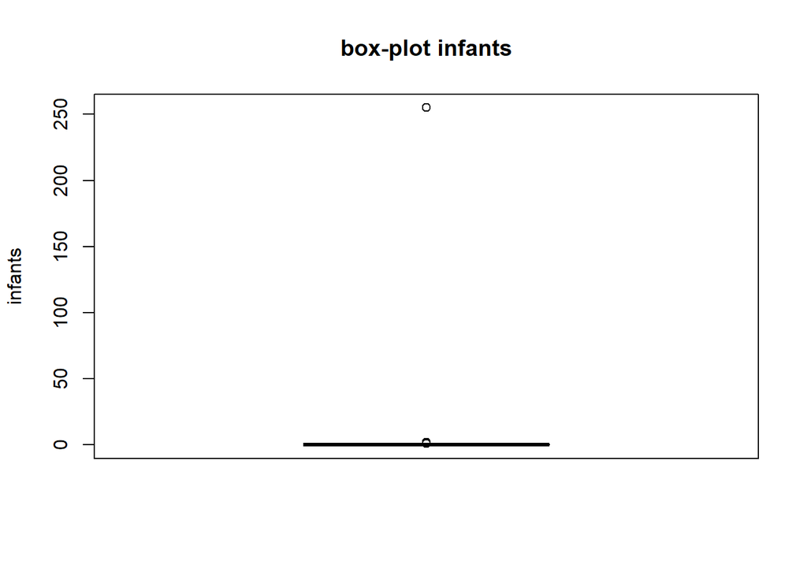

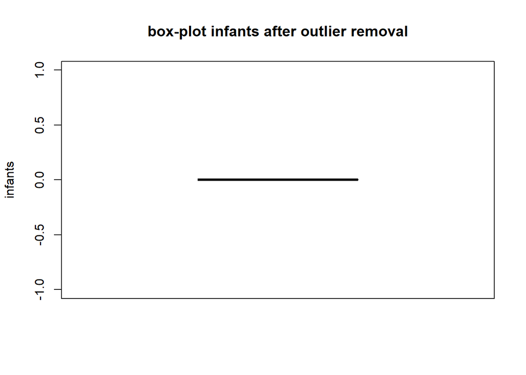

```r
boxplot(data$Infants, main= 'box-plot infants',ylab='infants')
outliers0 <- boxplot(data$Infants, plot=FALSE)$out
data <- data[-which(data$Infants %in% outliers0),]
boxplot(data$Infants,main='box-plot infants after outlier removal',ylab='infants')
```

After removing the outliers, the data only contains observaions with 0 infants. Hence, it would not be of any use in the analysis as all cases contains 0 infants. The variable Infants is removed from the dataframe.

```r
data$Infants<-NULL
```

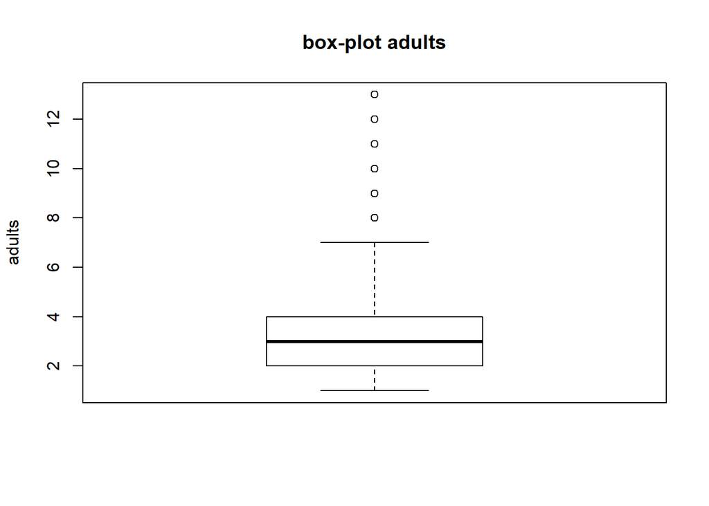

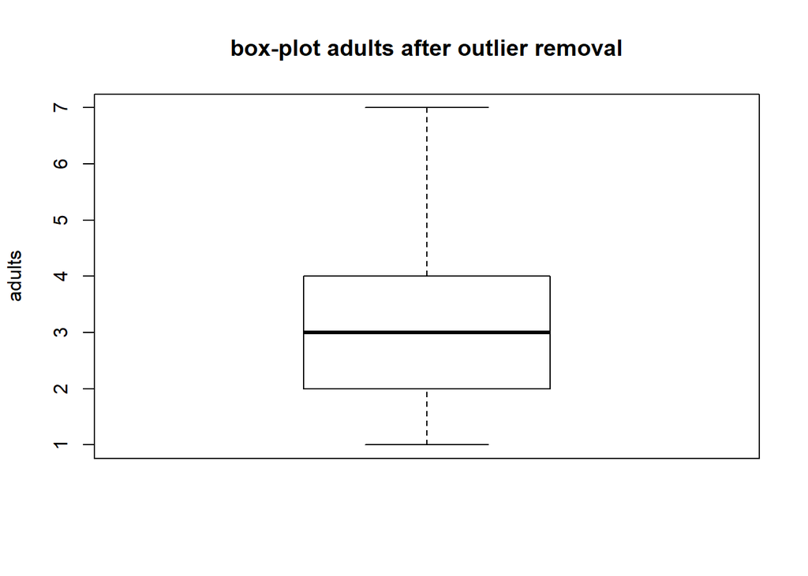

```r
boxplot(data$Adults,main='box-plot adults',ylab='adults')
outlierReplace(data,"Adults",which(data$Adults>10),NA)
outliers1 <- boxplot(data$Adults, plot=FALSE)$out
data <- data[-which(data$Adults %in% outliers1),]
boxplot(data$Adults,main='box-plot adults after outlier removal',ylab='adults')
```

A box plot method was used to deal with the outliers for the valiable ‘Children’

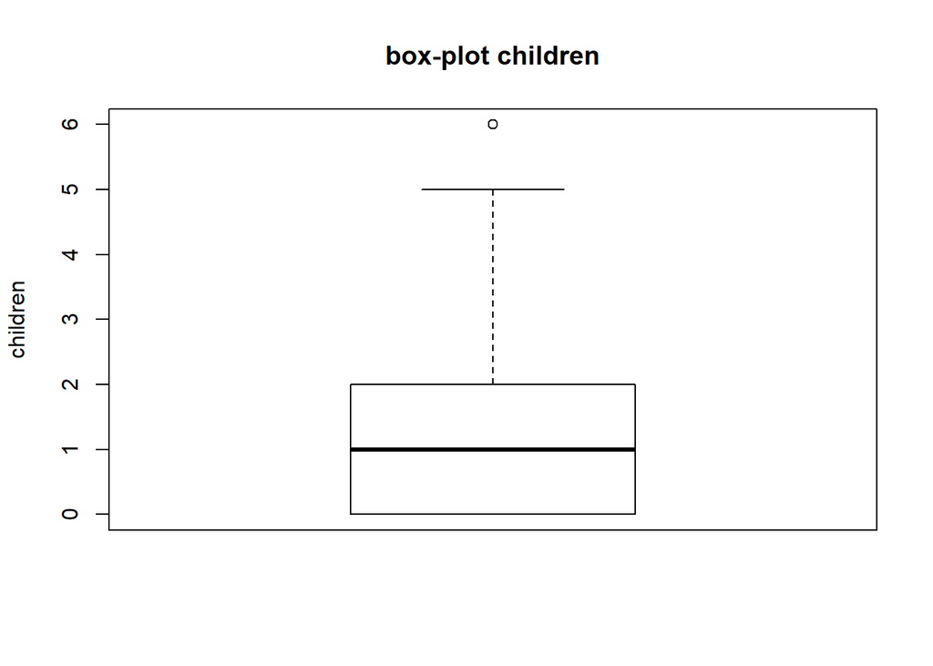

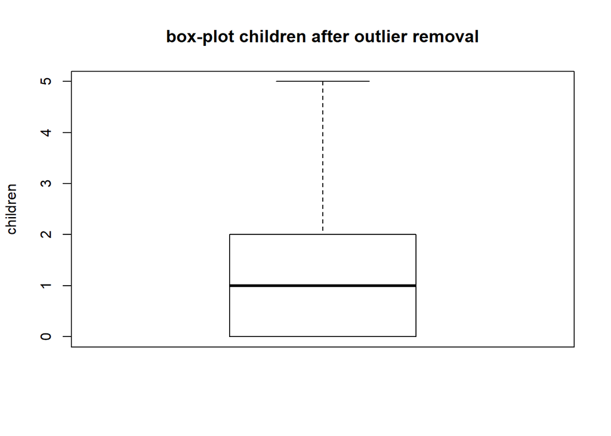

```r
boxplot(data$Children,main='box-plot children',ylab='children')
outliers3 <- boxplot(data$Children, plot=FALSE)$out
data <- data[-which(data$Children %in% outliers3),]
boxplot(data$Children, main='box-plot children after outlier removal',ylab='children')
```

Similarly outliers in Lead.Time was treated using the same method

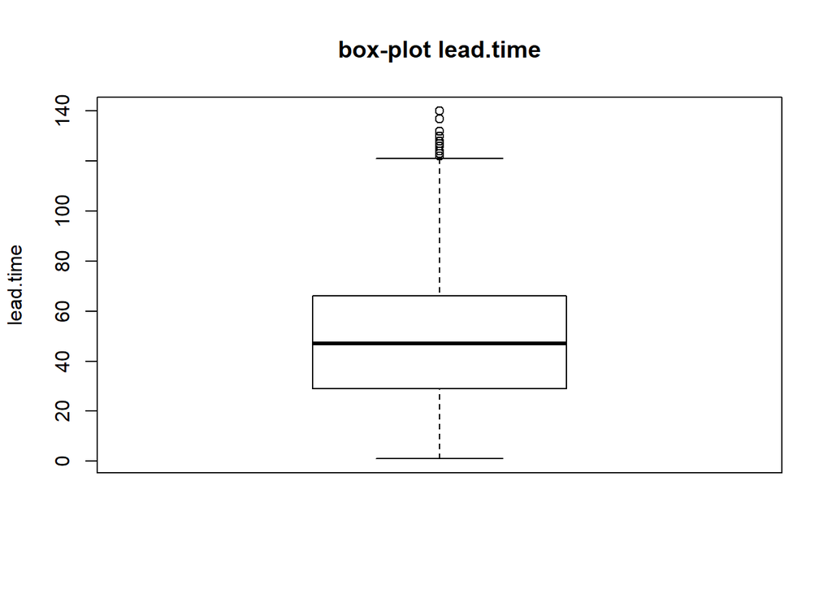

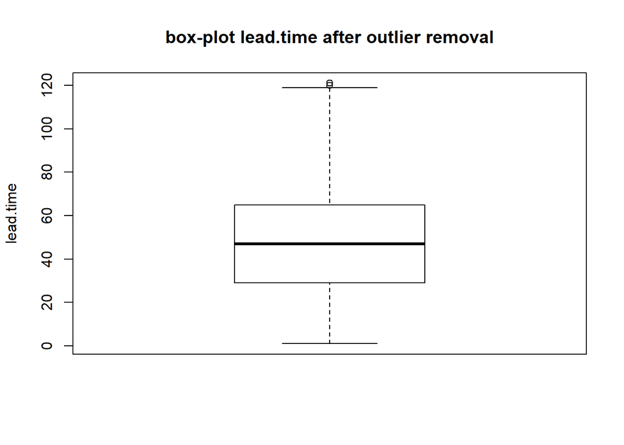

```r
boxplot(data$Lead.Time,main='box-plot lead.time',ylab='lead.time')
outliers4 <- boxplot(data$Lead.Time, plot=FALSE)$out
data <- data[-which(data$Lead.Time %in% outliers4),]
boxplot(data$Lead.Time, main='box-plot lead.time after outlier removal',ylab='lead.time')
```

#### Destination

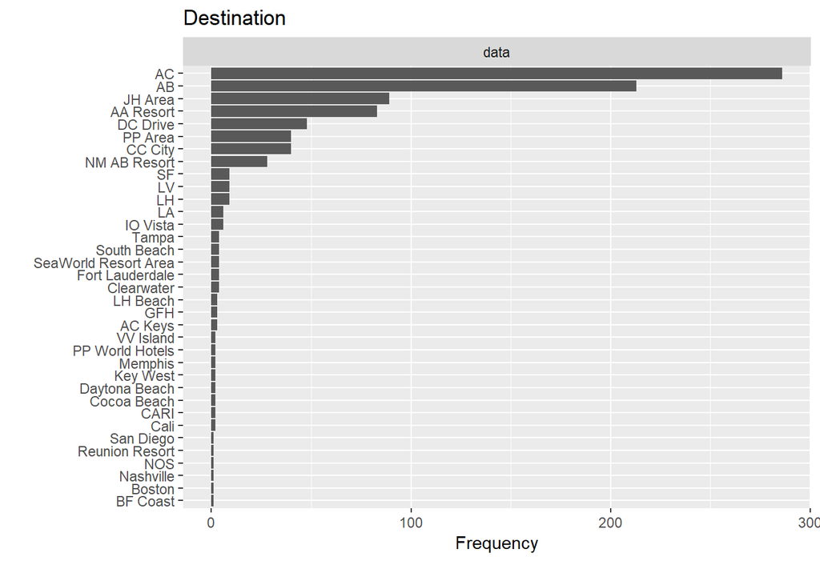

```r
plot_bar(data$Destination,title="Destination")
```

```r
data<-group_category(data=data, feature = "Destination", threshold=0.05, update=TRUE)
data$Destination<- factor(data$Destination)
```

New levels for Destination after combining rare levels

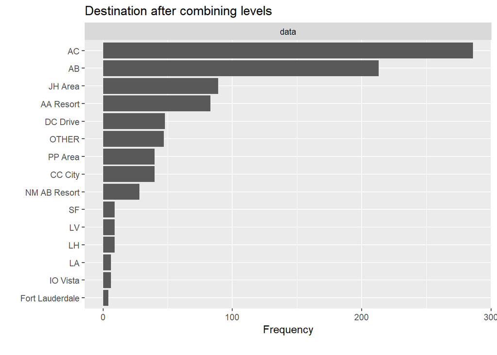

```r
plot_bar(data$Destination,title="Destination after combining levels")
```

#### Dep.Airport

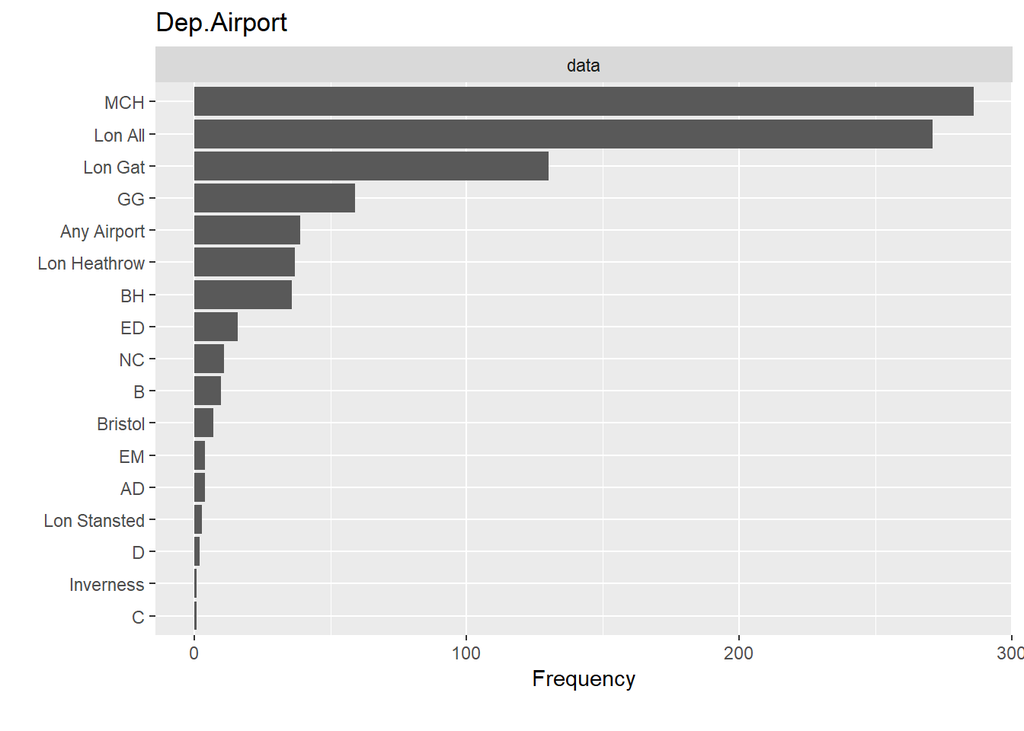

```r
plot_bar(data$Dep.Airport,title="Dep.Airport")
```

```r
data<-group_category(data=data, feature = "Dep.Airport", threshold=0.05,update=TRUE)
data$Dep.Airport<-factor(data$Dep.Airport)
```

New levels for Dep.Airport after combining rare levels

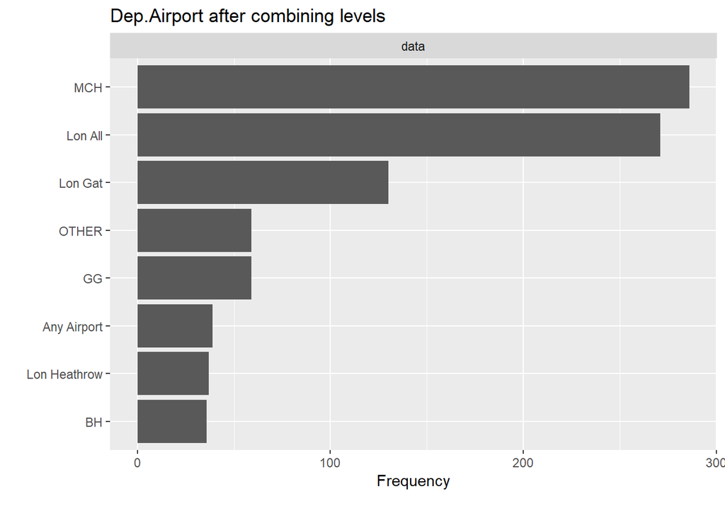

```r
plot_bar(data$Dep.Airport,title="Dep.Airport after combining levels")
```

#### Combine levels based on business logic

From the plot of Transport.Type it is identified that some of the points are unlabeled, we can treat the unlabelled points as ‘None Required’Combining unlabed points with the the ’None required’ level

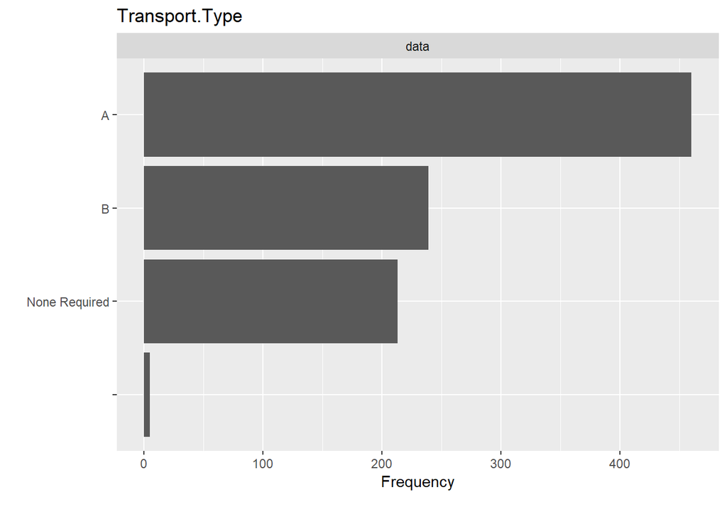

```r
plot_bar(data$Transport.Type,title="Transport.Type")
```

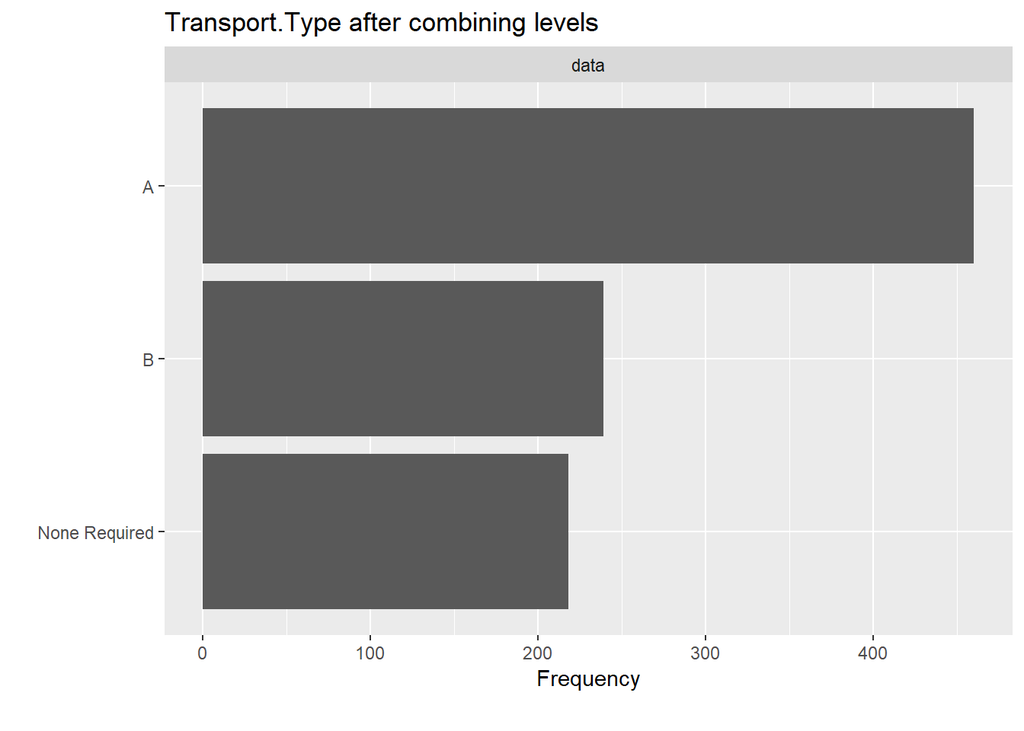

```r
data$Transport.Type <- with(data,  ifelse(Transport.Type %in% "A","A",
                                     ifelse(Transport.Type %in% "B", "B", "None Required")))
data$Transport.Type<- factor(data$Transport.Type)
plot_bar(data$Transport.Type,title="Transport.Type after combining levels")
```

#### Combine unlabbeled points in Accom.type into ‘None’

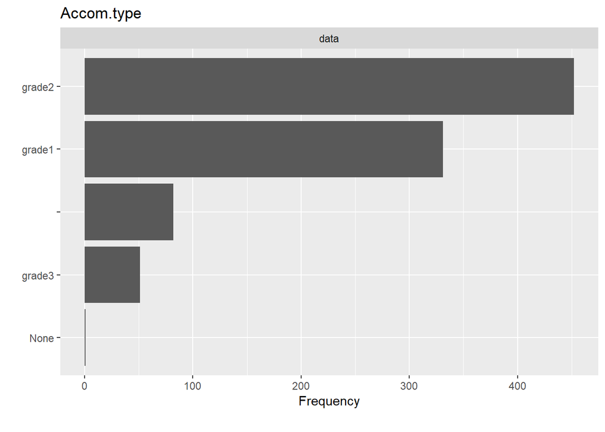

```r
plot_bar(data$Accom.type,title="Accom.type")
```

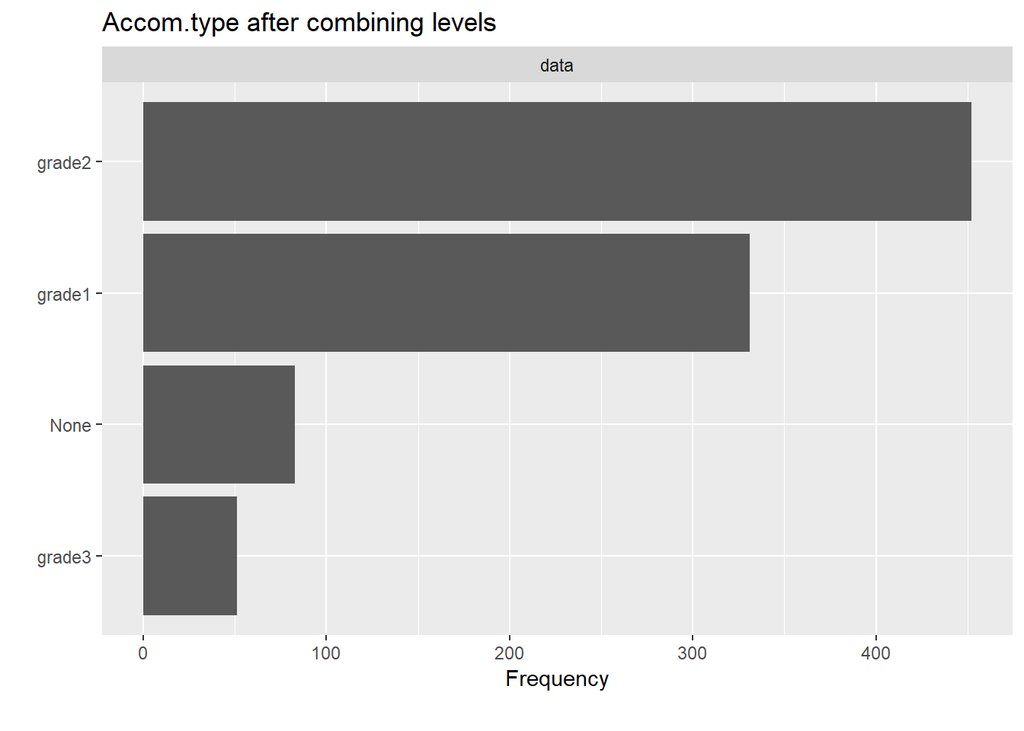

```r
data$Accom.type <- with(data,  ifelse(Accom.type %in% "grade2","grade2",
                                  ifelse(Accom.type %in% "grade1", "grade1",
                                     ifelse(Accom.type %in% "grade3", "grade3","None"))))

data$Accom.type<- factor(data$Accom.type)
plot_bar(data$Accom.type,title="Accom.type after combining levels")
```

It could be ideal to analyse based on gender than based on Title, converting title to M for male and F for female. An assumption is made that “Dr” refers to male

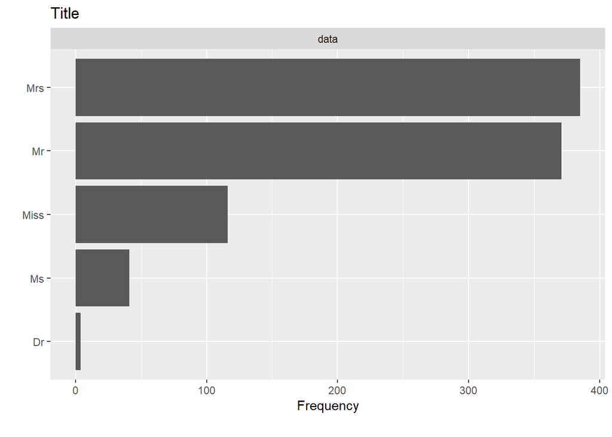

```r
plot_bar(data$Title, title="Title")
```

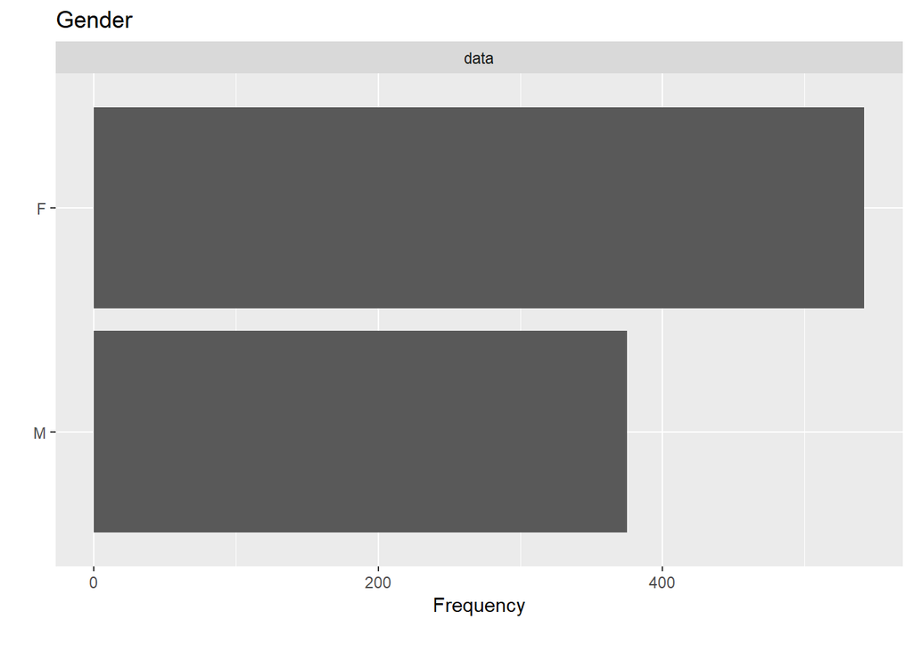

```r
data$Gender<- with(data, ifelse(Title %in% "Dr","M",
                                ifelse(Title %in% "Mr","M",
                                       ifelse(Title %in% "Ms","F",
                                              ifelse(Title %in% "Mrs","F","F")))))

data$Gender<-factor(data$Gender)
plot_bar(data$Gender, title="Gender")
```

The variable Booked.Status is the target variable and it would be ideal to convert it into ‘1’ and ‘0’ before modelling

```r
data$Booked.Status<-with(data,ifelse(Booked.Status %in% "YES","1","0"))
data$Booked.Status<-factor(data$Booked.Status)
```

#### Final check

```r
str(data)
```

```
## 'data.frame':    917 obs. of  29 variables:
##  $ Allocated.Time        : Factor w/ 3 levels "Extremely Fast",..: 2 2 2 2 2 2 2 2 2 2 ...
##  $ Web.or.Phone          : Factor w/ 2 levels "PHONE","WEB": 2 1 1 1 1 1 1 1 1 1 ...
##  $ Answered.by.specialist: Factor w/ 2 levels "0","1": 2 2 1 2 1 1 2 2 2 2 ...
##  $ Holiday.Type          : Factor w/ 6 levels "A","B","C","D",..: 2 1 1 2 1 1 1 5 1 1 ...
##  $ Accom.type            : Factor w/ 4 levels "grade1","grade2",..: 2 1 2 2 1 1 2 4 2 2 ...
##  $ Dep.Airport           : Factor w/ 8 levels "Any Airport",..: 8 7 8 4 7 5 4 4 4 6 ...
##  $ Lead.Time             : int  48 26 27 47 27 62 56 14 85 44 ...
##  $ Destination           : Factor w/ 15 levels " AA Resort"," AB",..: 4 8 5 15 2 2 1 15 1 3 ...
##  $ Duration              : num  14 14 14 17 14 14 14 14 14 10 ...
##  $ Adults                : int  2 2 2 2 2 3 2 3 1 4 ...
##  $ Children              : int  0 0 2 2 2 2 3 0 1 0 ...
##  $ Transport.Type        : Factor w/ 3 levels "A","B","None Required": 2 1 2 1 1 2 2 1 2 3 ...
##  $ Answered.Q            : Factor w/ 2 levels "NO","YES": 1 2 2 2 1 2 1 2 2 1 ...
##  $ Notes.Completed       : Factor w/ 2 levels "NO","YES": 1 1 1 1 1 2 1 2 1 1 ...
```

[output cut: 16 more lines]

```r
summary(data)
```

```
##         Allocated.Time Web.or.Phone Answered.by.specialist  Holiday.Type
##  Extremely Fast:242    PHONE:179    0:445                  A      :624
##  Fast          :122    WEB  :738    1:472                  B      :130
##  Slow          :553                                        C      : 26
##                                                            D      : 32
##                                                            E      :103
##                                                            RV Tour:  2
##
##   Accom.type       Dep.Airport    Lead.Time          Destination
##  grade1:331   MCH        :286   Min.   :  1.00    AC       :286
##  grade2:452   Lon All    :271   1st Qu.: 29.00    AB       :213
##  grade3: 51   Lon Gat    :130   Median : 47.00    JH Area  : 89
##  None  : 83   GG         : 59   Mean   : 48.65    AA Resort: 83
##               OTHER      : 59   3rd Qu.: 65.00    DC Drive : 48
##               Any Airport: 39   Max.   :121.00   OTHER     : 47
##               (Other)    : 73                    (Other)   :151
##     Duration         Adults         Children            Transport.Type
##  Min.   : 1.00   Min.   :1.000   Min.   :0.0000   A            :460
##  1st Qu.:13.00   1st Qu.:2.000   1st Qu.:0.0000   B            :239
##  Median :14.00   Median :3.000   Median :1.0000   None Required:218
##  Mean   :13.38   Mean   :3.305   Mean   :0.8833
##  3rd Qu.:14.00   3rd Qu.:4.000   3rd Qu.:2.0000
##  Max.   :28.00   Max.   :7.000   Max.   :5.0000
##                  NA's   :9
##  Answered.Q Notes.Completed  Title     Enquiry.Comments Booked.Status
##  NO :447    NO :659         Dr  :  4   NO :685          0:688
##  YES:470    YES:258         Miss:116   YES:232          1:229
##                             Mr  :371
##                             Mrs :385
##                             Ms  : 41
##
##
##  EnquiryYear  EnquiryMonth   EnquiryDay      EnquiryWeekday DepYear
##  2017:443    1      :162   Min.   : 1.00   Friday   : 88    2017:120
##  2018:423    5      : 95   1st Qu.: 8.00   Monday   :139    2018:384
##  2019: 51    4      : 89   Median :15.00   Saturday :110    2019:358
##              9      : 85   Mean   :15.73   Sunday   :206    2020: 55
##              6      : 73   3rd Qu.:23.00   Thursday :109    2021:  0
##              7      : 72   Max.   :31.00   Tuesday  :130
##              (Other):341                   Wednesday:135
##     DepMonth       DepDay          DepWeekday       Enquiry.Timecat
##  8      :224   Min.   : 1.00   Friday   :124   Business_Hour:685
##  10     :125   1st Qu.: 7.00   Monday   :143   Closed       :232
##  7      :116   Median :15.00   Saturday :176
##  4      : 85   Mean   :15.14   Sunday   : 90
##  9      : 80   3rd Qu.:22.00   Thursday :114
##  5      : 78   Max.   :31.00   Tuesday  :127
##  (Other):209                   Wednesday:143
##  Enquiry.Time_class DepartureSeason Gender
##  afternoon:291      winter: 74      F:542
##  morning  :536      spring:211      M:375
##  night    : 90      summer:391
##                     fall  :241
##
##
##
```

#### Minor changes (convert Duration to an integer)

```r
data$Duration<-as.integer(data$Duration)
```

#### Save the cleaned data as a csv

```r
write.csv(data,file='ReadyforModelling.csv')
```